# Primer of Ecology with $\textsf{R}$: Team Lumpsucker Ch. 3 Problems

Compiled on Thu Sep 12 11:16:01 2019 by margaretwilson

```r
knitr::opts_chunk$set(fig.width = 6, fig.height = 4, # fig.path = 'Figs/',
                      echo = TRUE, message = FALSE, warning = FALSE)

library(tidyverse)
library(RColorBrewer)

### The book has an R package!
library(primer) # install.packages('primer')
```

# Chapter 3: Density Dependent Growth

## 3.1. Dynamics of an annual plant

1. Calculate $r_d$ of an annual plant that has a maximum growth rate of $N_{t+1}/N_t = 2$ at very, very small population sizes.
2. Calculate the appropriate per capita density dependent effect of an annual plant with a carrying capacity K of 100 inds $\cdot$ m<sup>-2</sup>.
3. Write the appropriate logistic growth equation that incorporates the intrinsic growth of (a) and the density dependence of (b).
4. Graph the 10 y dynamics ($t$ = 0,…, 10$) of the annual plant in (a) and (b), starting with $N_0 = 1$.

### Molly’s attempts

1. Calculate $r_d$ of an annual plant that has a maximum growth rate of $N_{t+1}/N_t = 2$ at very, very small population sizes.

$$N_{t+1} = N_t + r_d * N_t$$
$$N_{t+1}/N_t = 1 + r_d = 2$$
$$r_d = 1$$

2. Calculate the appropriate per capita density dependent effect of an annual plant with a carrying capacity K of 100 inds $\cdot$ m<sup>-2</sup>.
   $$1/\alpha = k$$
   $$\alpha = 1/100 = 0.01$$
3. Write the appropriate logistic growth equation that incorporates the intrinsic growth of (a) and the density dependence of (b).
   $$N_{t+1} = N_t + r_d * (1 - N_t/K) * N_t$$
   $$N_{t+1}/N_t = 1 + 1 * (1-N_t/100)$$
4. Graph the 10 y dynamics ($t = 0,..., 10$) of the annual plant in (a) and (b), starting with
   $$N_0 = 1$$
   .

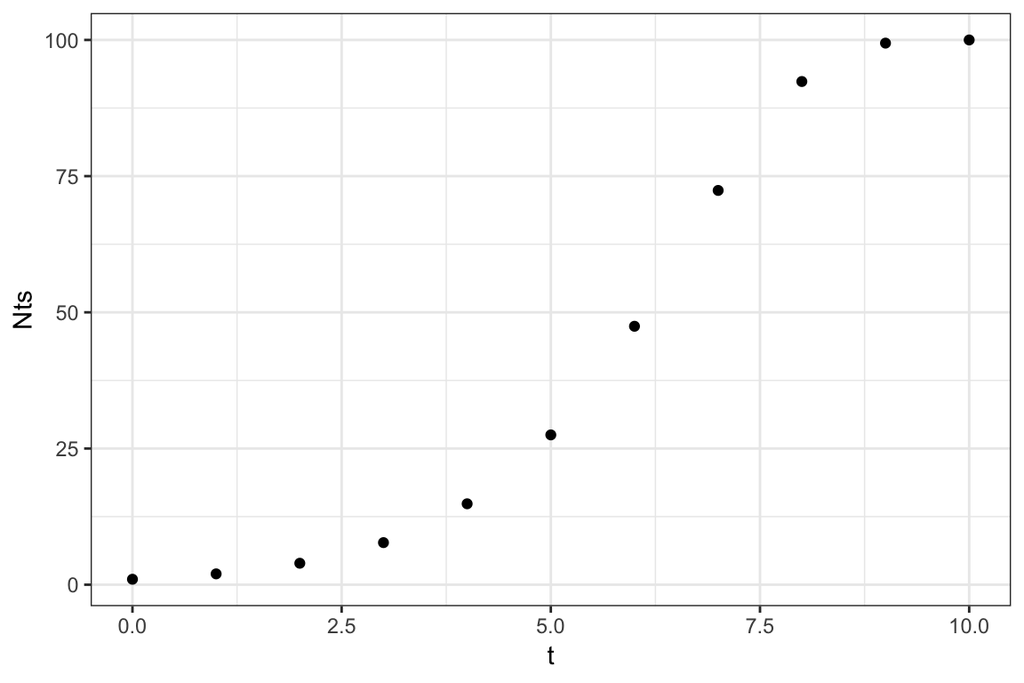

```r
dlogistic <- function(alpha = 0.01, rd = 1, N0 = 1, t = 10) {
  N <- c(N0, numeric(t))
  for (i in 1:t) N[i + 1] <- {
      N[i] + rd * N[i] * (1 - alpha * N[i])
    }
  return(N)
}

nts_df <- dlogistic() %>%
  as.data.frame() %>%
  setNames(c('Nts')) %>%
  mutate(t=c(0:10))

ggplot(nts_df, aes(x = t, y = Nts)) +
  theme_bw() +
  geom_point()
```

### Casey’s solutions:

1. Since the plant is doubling each interval, seems obvious that $r_d$ = 1. More formally:
   $$N_{t+1} = \lambda N_t = N_t(1 + r_d)$$
   Since $N_{t+1} = 2N_t$ then $1 + r_d = 2$.
2. Per capita density dependent effect is $\alpha = 1/K = 0.01$.
3. $N_{t+1} = N_t + r_d(1 - \alpha N_t) N_t$ or $N_t + (1)(1 - .01N_t) N_t$ or $N_t - .01N_t^2 + 1$

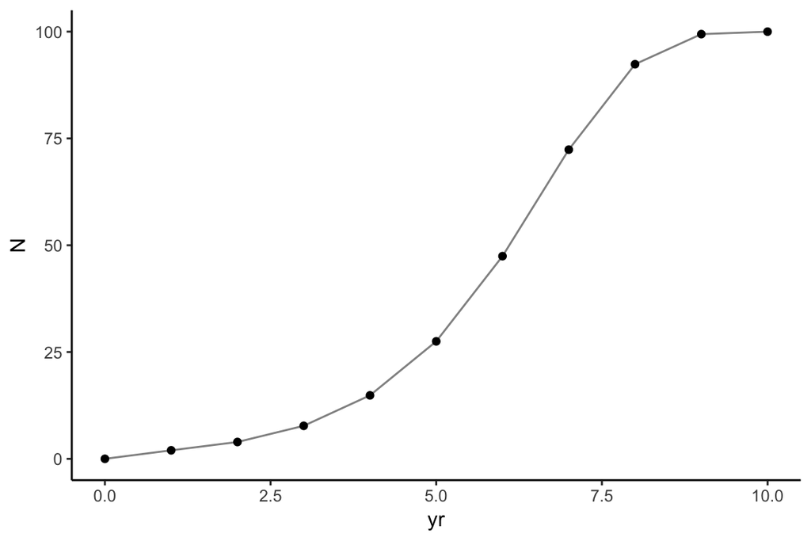

```r
calc_ntplus1 <- function(N, r_d, a) {
  N_tplus1 <- N + r_d * (1 - a * N) * N
}

N_0 <- 1; r_d <- 1; a <- 0.01
yrs <- 10

N_vec <- vector('numeric', length = yrs)
N_vec[1] <- calc_ntplus1(N_0, r_d, a)
for (yr in 2:yrs) {
  N_vec[yr] <- calc_ntplus1(N_vec[yr - 1], r_d, a)
}
prob1_df <- data.frame(yr = 0:yrs,
                       N = c(0, N_vec))

ggplot(prob1_df, aes(x = yr, y = N)) +
  theme_classic() +
  geom_point() +
  geom_line(alpha = .5)
```

### 3.1 Sean’s solution:

1. Calculating $r_d$

$N_{t+1} = \lambda N_t = N_t (1 + r_d)$

$N_{t+1}/N_t = 1 + r_d$

$2 = 1 + r_d$

$r_d = 1$

2. Calculating $\alpha$

$0 = r_d - r_d(1 - \alpha N_t)$

$N_t = 1/\alpha$

$100 = 1/\alpha$

$\alpha = 1/100 = 0.01$

3. Write logistic growth equation

$N_{t+1} = \lambda N_t = (1 + r_d(1 - \alpha/K) N_t$

## 3.2. Dynamics of *E. coli*

1. Calculate $r$ of *E. coli* that has a doubling time of 30 min. Express this rate in hours.
2. Calculate the per capita density dependent effect of an *E. coli* culture that grows logistically over a 24 h period, and which levels off at a density of 10<sup>7</sup> CFU$\cdot$mL<sup>−1</sup>$ (CFU is colony forming units — for *E. coli* its is equivalent to individuals).
3. Graph the 50h dynamics ($t = 0,..., 50$) of the *E. coli* population in (a) and (b), starting with $N_0 = 1000$.

### Molly’s attempts

1. Calculate $r$ of *E. coli* that has a doubling time of 30 min. Express this rate in hours.

$$2N = Ne^{rt}$$
$$r = ln(2)/t$$
Here t = .5hr
$$r = ln(2)/.5 = 1.38\text{ hr}^{-1}$$

2. Calculate the per capita density dependent effect of an *E. coli* culture that grows logistically over a 24 h period, and which levels off at a density of 10<sup>7</sup> CFU$\cdot$mL<sup>−1</sup>$ (CFU is colony forming units — for *E. coli* its is equivalent to individuals).

$$\alpha=1/k=10^{-7}\text{ mL/CFU}$$

3. Graph the 50h dynamics ($t = 0,..., 50$) of the *E. coli* population in (a) and (b), starting with $N_0 = 1000$.

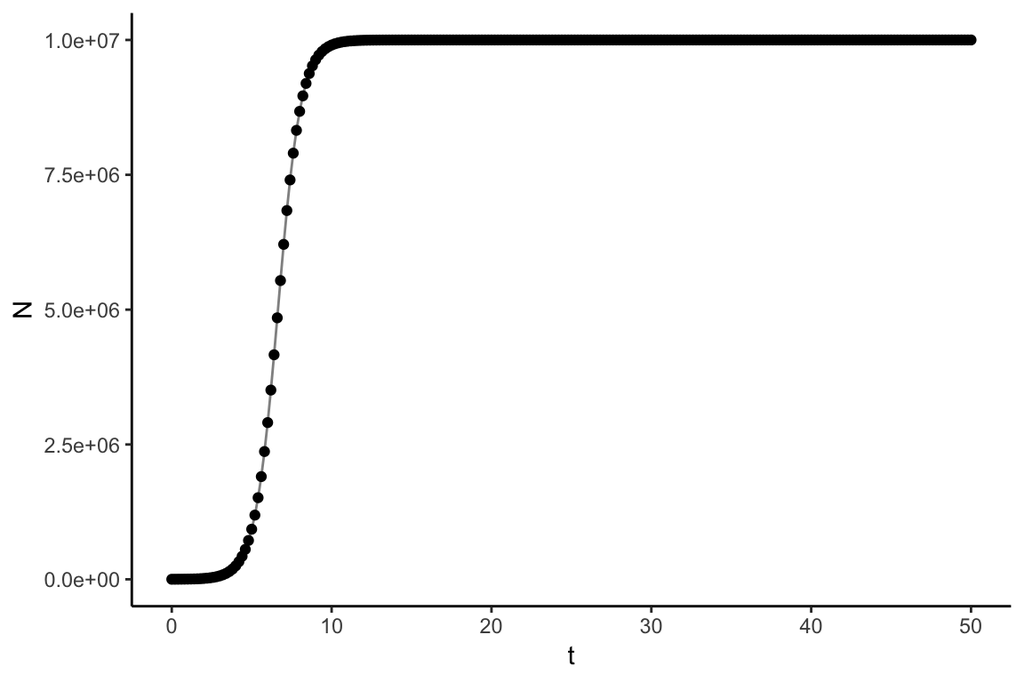

```r
# from the text:
clogistic <- function(times, y, parms) {
  n <- y[1]
  r <- parms[1]
  alpha <- parms[2]
  dN_dt <- r * n * (1 - alpha * n)
  return(list(c(dN_dt)))
}

prms <- c(r = log(2) / .5, a = 1e-7)
N_0 <- 1000
t_vec <- seq(0, 50, .2)

library(deSolve)
N_out <- ode(y = N_0, times = t_vec, clogistic, parms = prms)

nts_df2 <- as.data.frame(N_out) %>%
  setNames(c('t', 'N'))
ggplot(nts_df2, aes(x = t, y = N)) +
  theme_classic() +
  geom_point() +
  geom_line(alpha = .5)
```

### Casey’s solutions:

1. For exponential growth:
   $$2N = Ne^{rt} \Rightarrow \ln 2 = rt \Rightarrow r = \ln 2 / t$$
   In this case, $t = .5 \text{ hr}$ so $r = \ln 2 / .5 = 1.38\text{ hr}^{-1}$.
2. Per cap density dependent effect $\alpha = 1/K = 10^{-7} \text{ mL/CFU}$
3. $N(t) = N_0e^{rt}$: here I’m using code from the book.

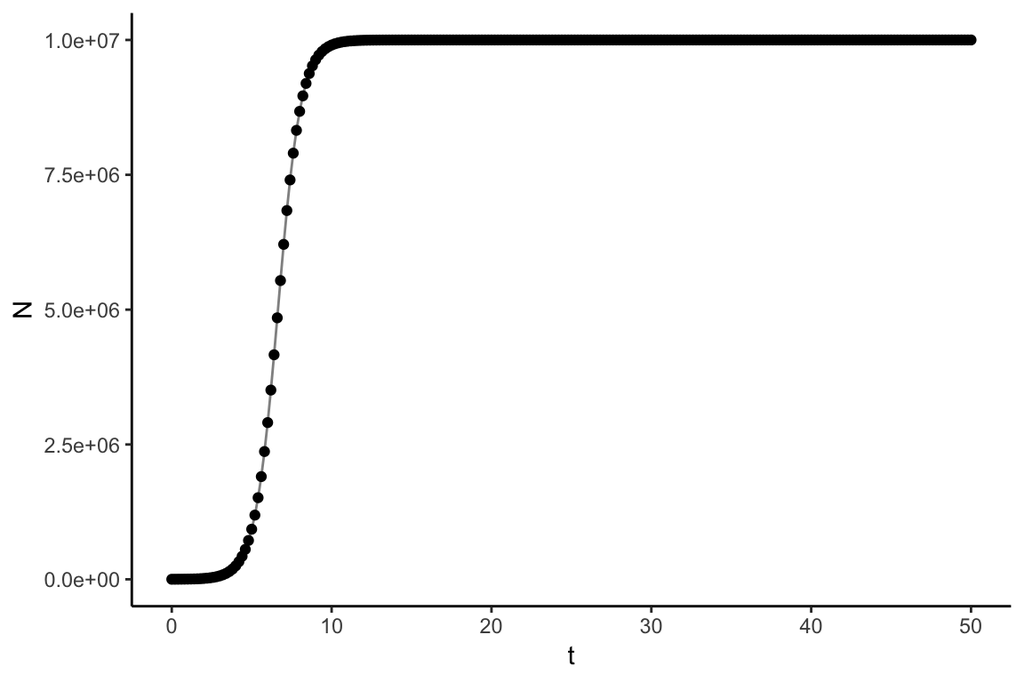

```r
clogistic <- function(times, y, parms) {
  n <- y[1]
  r <- parms[1]
  alpha <- parms[2]
  dN_dt <- r * n * (1 - alpha * n)
  return(list(c(dN_dt)))
}

prms <- c(r = log(2) / .5, a = 1e-7)
N_0 <- 1000
t_vec <- seq(0, 50, .2)

library(deSolve)
N_out <- ode(y = N_0, times = t_vec, clogistic, parms = prms)

prob2_df <- as.data.frame(N_out) %>%
  setNames(c('t', 'N'))
ggplot(prob2_df, aes(x = t, y = N)) +
  theme_classic() +
  geom_point() +
  geom_line(alpha = .5)
```

## 3.3. Nonlinear Density Dependence

Sibly et al. [188] found that most species have nonlinear and concave-up density dependence. They use the $\theta$-logistic growth model.

1. Create a theta-logistic continuous growth model for use with the `ode()` function in the `deSolve` package.
2. Show that with $\theta = 1$, it is identical our function `clogistic` above.
3. Graph $N$ for $t = 0,..., 100$ using a few different values of $\theta$ and explain how $\theta$ changes logistic growth.

### Casey’s solutions

1. the function:

```r
theta_logistic <- function(times, y, params) {
  n <- y[1]
  r <- params[1]
  alpha <- params[2]
  theta <- params[3]
  dN_dt <- r * n * (1 - (alpha * n)^theta)
  return(list(c(dN_dt)))
}
```

2. For logistic growth, $\frac{dN}{dt} = rN(1 - \alpha N)$. For theta logistic, $\frac{dN}{dt} = rN(1 - [\alpha N]^\theta)$, so if $\theta = 1$ then the two equations are identical (and thus the functions become identical).
3. Using the same parameters as above, and varying $\theta$:

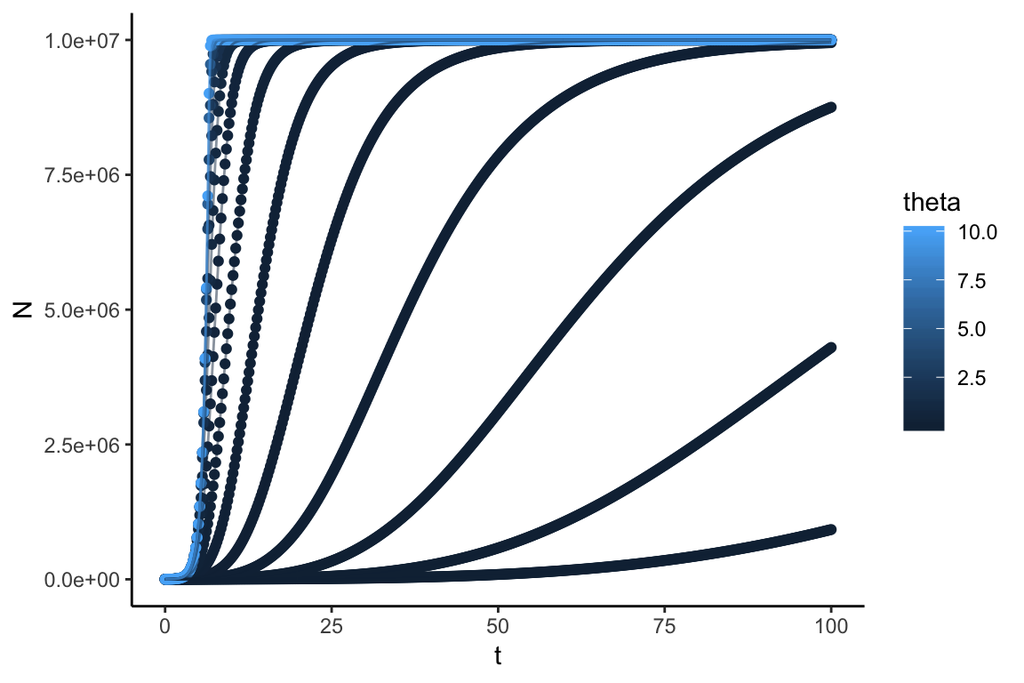

```r
N_0 <- 1000
t_vec <- seq(0, 100, .2)
theta_vec <- 10^seq(-2, 1, .25)

tmp_list <- vector('list', length = length(theta_vec))

for(i in seq_along(theta_vec)) {

  th <- theta_vec[i]
  params <- c(r = log(2) / .5, alpha = 1e-7, theta = th)

  library(deSolve)
  N_out <- ode(y = N_0, times = t_vec, theta_logistic, parms = params)

  tmp_df <- as.data.frame(N_out) %>%
    setNames(c('t', 'N')) %>%
    mutate(theta = th)
  tmp_list[[i]] <- tmp_df
}

prob3_df <- bind_rows(tmp_list)

ggplot(prob3_df, aes(x = t, y = N, color = theta)) +
  theme_classic() +
  geom_point() +
  geom_line(alpha = .5, aes(group = theta))
```

## 3.4. Harvested Populations

The logistic growth equation and other similar equations have been used and abused in efforts to achieve a *maximum sustained yield* of a harvested population. The immediate goal of maximum sustained yield management practices is to kill only the number of individuals that reduces the population to half of its carrying capacity, assuming that eq. 3.13 describes the population growth. Answer the questions below to help you explain why this would be a goal.

1. Find expressions for population growth rates when $N = K/4, K/2, 3K/4$ (substitute these values for $N$ in eq. 3.13, and show your work). Which of these results in the highest population growth rate? How do these relate to the management of a harvested population?
2. Show the derivation of the partial derivative of the continuous logistic growth model, with respect to N (i.e., $\partial \dot{N} / \partial N$). Solve for zero to determine when total population growth rate reaches a maximum. Show your work.
3. What would be the ecological and economic rationale for not killing more individuals, and keeping $N > K/2$?
4. What would the consequences be for the population if you assume linear density dependence $(1 − \alpha/N)$, but in fact the population is governed by non-linear density dependence where $\theta < 1$ and $\theta > 1$ (Figs. 3.13a - 3.13c)?
5. What economic benefit would you gain if you harvested the entire popula- tion all at once (and eliminated it from the face of the planet)? What could you do with all that money?
6. How would you incorporate both harvesting and economic considerations into your logistic growth model?

### Molly’s attempts

1. Find expressions for population growth rates when $N = K/4, K/2, 3K/4$ (substitute these values for $N$ in eq. 3.13, and show your work). Which of these results in the highest population growth rate? How do these relate to the management of a harvested population?

*N=K/4:*
$$\frac{dN}{dt}=r*\frac{K}{4}*\frac{K-\frac{K}{4}}{K})$$
$$\frac{dN}{dt}=r*\frac{1}{4}*K*\frac{3}{4}$$
$$\frac{dN}{dt}=\frac{3}{16}*r$$

*N=K/2:*
$$\frac{dN}{dt}=\frac{1}{4}*r$$

*N=3K/4:*
$$\frac{dN}{dt}=\frac{3}{16}*r$$

2. Show the derivation of the partial derivative of the continuous logistic growth model, with respect to N (i.e., $\partial \dot{N} / \partial N$). Solve for zero to determine when total population growth rate reaches a maximum. Show your work.

*see notes…*

3. Keeping $N > K/2$ is a precautionary guideline that allows for environmental variability, risk of harvesting above mangement regulations, etc. At $N = K/2$, the growth rate is maximized, so harvesting beyond this point would have the growth rate declining (population could still be growing, but not as quickly, which would mean economic losses in the long run)
4. Assuming linear density dependence $(1 − \alpha/N)$ when in fact $\theta < 1$ and $\theta > 1$ would lead to over- or underestimates of MSY harvest levels, because $N = K/2$ shifts with $\theta$.
5. What economic benefit would you gain if you harvested the entire population all at once (and eliminated it from the face of the planet)? What could you do with all that money?
6. How would you incorporate both harvesting and economic considerations into your logistic growth model?

### Casey’s solutions:

1. Eqn 3.13: $\frac{dN}{dt} = rN\left(\frac{K - N}{K}\right)$. The middle term becomes .75, .5, and .25 respectively for $N = K/4, K/2, 3K/4$; so the growth rate $\frac{dN}{dt} = .75rN, .50rN, .25rN$ respectively.
2. $\partial \dot{N} / \partial N = \partial \frac{dN}{dt} / \partial N$:
   $$\frac{\partial}{\partial N} rN\left(\frac{K - N}{K}\right)$$
   differentiating by parts:
   $$r \times \frac{K - N}{K} + rN \times -\frac{1}{K}$$
   $$\frac{r}{K}(K - 2N)$$
   solve for $\partial \dot{N} / \partial N = 0$:
   $$K = 2N \quad \Longrightarrow \quad N = K/2$$
3. Setting a target to maintain $N > K/2$ ecologically allows for uncertainty in population estimates and carrying capacity estimates, i.e. a precautionary principle. From an economics perspective, targeting fish at less dense populations is more costly, so this will shift the optimal population slightly higher to maximize (profit - cost); additionally, the benefit of leaving extra fish compounds over time, so the max economic yield is typically where the growth rate is equal to the discount rate.
4. Assuming linear density dependence, when $\theta < 1$, means your growth rate assumption will be too high, and thus the harvest targets (equal to predicted growth rate) will be too high. When $\theta > 1$, harvest targets will be too low, resulting in an underexploited stock.
5. Harvesting the entire population and investing would provide a long term return at the interest rate of the investment.
6. Since cost is probably related to density (as density decreases, costs increase), you’d need to account for total profits, not gross revenue from harvest; and you’d harvest down to the point where the long term expected value of the fish left in the water (growing and harvesting to that level every year forever) is equal to the value of harvesting everything now and putting the profits into other interest-earning investments.

## 3.5. Environmental Variability

Most environments change continually. Temperature, resource availability, changes in predator or pathogen abundance all influence the carrying capacity of the environment.

1. Use the discrete version of the logistic growth equation to model a population in a variable environment. Do this by creating a discrete logistic growth function that adds (or subtracts) a random amount to $K$ in each time step. Use one of the many functions that can draw random numbers from particular distributions (e.g., `rpois()`, `rlnorm()`, `runif()`). You might start by playing with one of the random number generators:

   ```
   Kstart <- 100; time <- 1:20; K <- numeric(20);
   for(i in 1:20) K[i] <- Kstart + rnorm(1, m=0, sd=5);
   plot(time, K).
   ```

2. All distributions are characterized by their moments. For instance, the Normal distribution is typically defined by its mean, $\mu$, and variance, $\sigma^2$. Focus on just one moment of your selected distribution in (a), and use your simulations to determine quantitatively the relation between $K$ and the resulting $N$ derived from the discrete growth model. For instance, you might vary the standard deviation of the random normal distribution that contributes to $K$, and examine how the standard deviation of $K$, $\sigma_K$, relates to mean $N$, $\mu_N$.
3. Create a reddened time series for K (see note below) (Hint: What are the values of `x` and `y` when you do `x <- sample(c(-1,0,1), 20, replace=TRUE); y <- cumsum(x)` ?). Use this time series to create a reddened population dynamic. (Hint: First create the vector of reddened $K$’s equal in length to your time series. Then create a growth function that can access the vector, e.g.

   ```
   DLG.RK <- function(alpha = 0.001, rd = 1, N0 = 10, gens = 20, K = K.red)
   ```

   Then, inside the for loop, use an indexed `K`, such as `1 - N[t]/K[t]`.

> Note: *Environmental factors such as temperature frequently vary in a gradual fashion, such that if the weather is hot today, it is likely to be hot tomorrow. Such variation is described in terms of auto-correlation or a spectral distribution or color [67,155]. Spectral decomposition of a times series involves a description of the series in terms of waves of different wavelengths or frequencies. White noise is variation that is described by equal contributions of all wavelengths (hence the term “white”), and it is a series that is completely random from one time step to the next. Reddened environmental variation is variation that is described by a predominance of longer wavelengths (hence the term “red”), and it is a series in which values tend to change gradually, where values that are close together in time tend to be more similar, or auto-correlated. Spectral variation is also referred to as 1/f noise (“one over f noise”).*

### Casey’s solutions:

1. Define a function similar to 3.1a with a stochastic carrying capacity modeled as normal distribution around a mean:

```r
calc_dlog_stoch <- function(N, r_d, K, K_sd = 0, K_lim = 20) {
  ### K is mean, K_sd is std dev around the mean...
  ### limit K_real to range of (K/K_lim, K*K_lim)
  while(TRUE) {
    K_real <- rnorm(1, mean = K, sd = K_sd)
    if(K_real < K_lim * K & K_real > K / K_lim) break()
  }
  N_tplus1 <- N * (1 + r_d * (K_real - N) / K_real)
  if(N_tplus1 < 0) {
    ### no pops less than zero!
    N_tplus1 <- 0
  }
  return(N_tplus1)
}
```

2. Run a few iterations at different standard deviations around the same mean

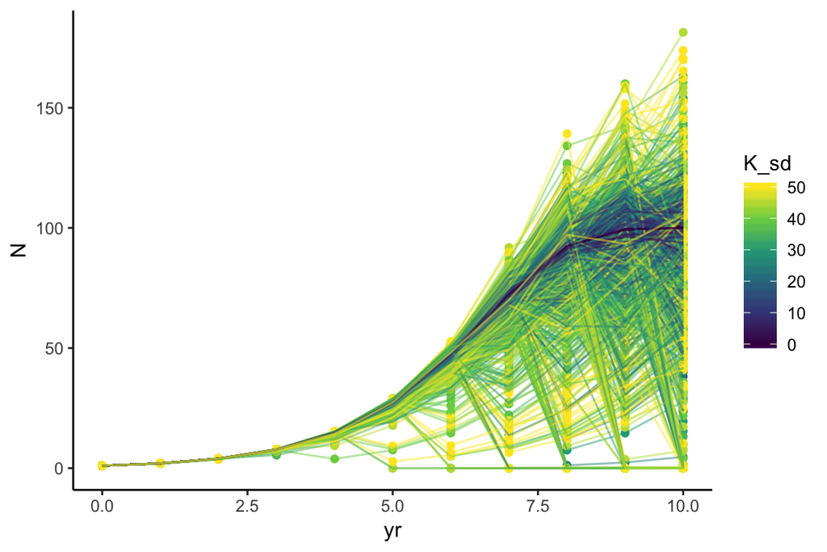

```r
N_0 <- 1; r_d <- 1; K <- 100
yrs <- 10
sims <- 100

set.seed(12345)
K_sd_vec <- seq(0, 50, 5)

### Initialize a list to store simulations at various K_sd values
K_stoch_list <- vector('list', length = length(K_sd_vec))

for(i in seq_along(K_sd_vec)) {
  ### Loop over each K_sd value, with a number of sim iterations
  K_sd <- K_sd_vec[i]

  ### Initialize the sims list
  sims_list <- vector('list', length = sims)

  for(sim in 1:sims) {
    ### loop over a number of simulations
    N_vec <- vector('numeric', length = yrs)
    N_vec[1] <- calc_dlog_stoch(N_0, r_d, K, K_sd)

    for (yr in 2:yrs) {
      ### loop along the vector of years
      N_vec[yr] <- calc_dlog_stoch(N_vec[yr - 1], r_d, K, K_sd)
    } ### end of year-to-year loop

    ### assemble the year vector for this simulation into a dataframe
    ### then put it into the sims list
    N_df <- data.frame(yr = 0:yrs,
                       N = c(N_0, N_vec)) %>%
      mutate(sim = sim, K_sd = K_sd)
   sims_list[[sim]] <- N_df

  } ### end of sim loop

  K_stoch_list[[i]] <- bind_rows(sims_list)

}

K_stoch_df <- bind_rows(K_stoch_list) %>%
  mutate(sim1 = paste(sim, K_sd))

K_stoch_plot <- ggplot(K_stoch_df, aes(x = yr, y = N, color = K_sd)) +
  theme_classic() +
  geom_point() +
  geom_line(alpha = .5, aes(group = sim1)) +
  scale_color_viridis_c()

print(K_stoch_plot)
```

As part b) suggests, we can also look at the distribution of $N$ as the standard deviation $\sigma_K$ changes.

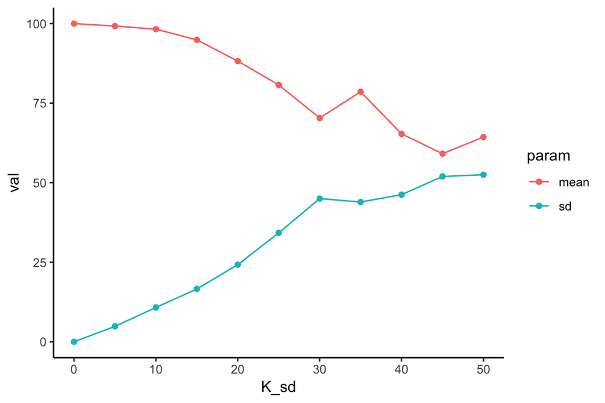

```r
K_endpoints <- K_stoch_df %>%
  filter(yr == max(yr)) %>%
  group_by(K_sd) %>%
  summarize(mean = mean(N), sd = sd(N)) %>%
  gather(param, val, mean, sd)

ggplot(K_endpoints, aes(x = K_sd, y = val, color = param, group = param)) +
  geom_point() +
  geom_line() +
  theme_classic()
```

3. define a function that generates a vector of $N$ using a “reddened” $K$.

```r
calc_dlog_red <- function(N_0, r_d, K_0, t, red = 0) {
  ### K_0 is starting val, red is the +/- increment to K each year
  ### default is constant K
  dK_vec <- sample(-1:1, t, replace = TRUE) * red
  K_vec <- cumsum(c(K_0, dK_vec))

  N_vec <- vector('numeric', length = t + 1)
  N_vec[1] <- N_0
  for (i in 1:t) { # i <- 2
    N_vec[i + 1] <- N_vec[i] * (1 + r_d * (K_vec[i] - N_vec[i]) / K_vec[i])

    if(N_vec[i + 1] < 0) {
      ### no pops less than zero!
      N_vec[i + 1] <- 0
    }
  }

  results_df <- data.frame(year = 0:t, N = N_vec, K = K_vec)
  return(results_df)
}
```

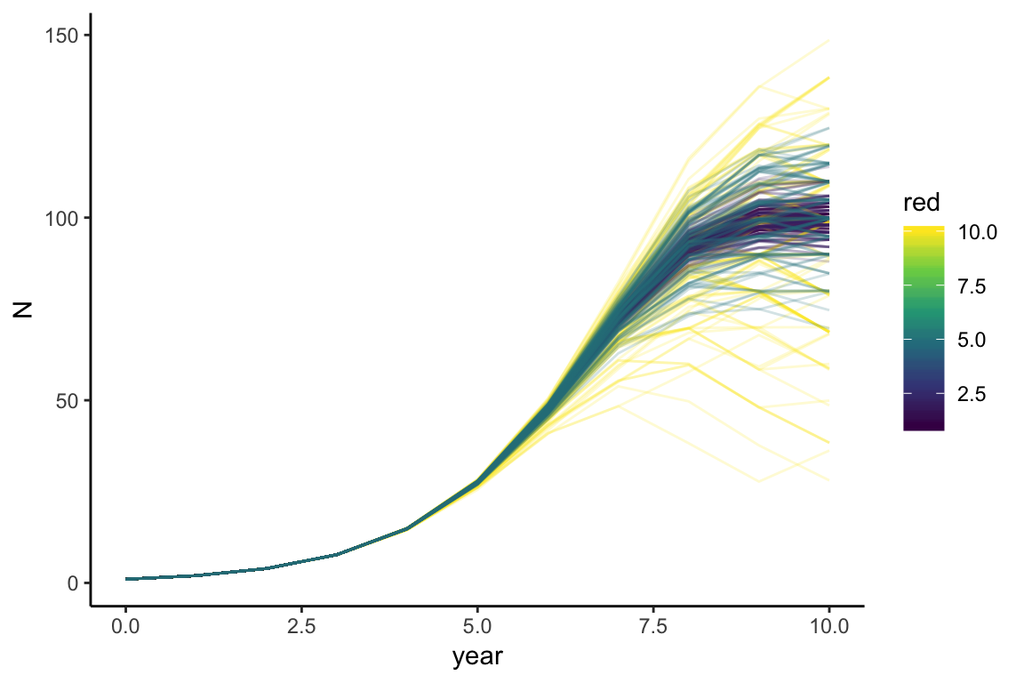

```r
N_0 <- 1; r_d <- 1; K <- 100
yrs <- 10
sims <- 100
red_vec <- c(1, 2, 5, 10)

K_red_list <- vector('list', length = length(red_vec))

for(i in seq_along(red_vec)) {
  # i <- 1
  red <- red_vec[i]
  K_red_list[[i]] <- lapply(1:sims, FUN = function(sim) {
    N_df <- calc_dlog_red(N_0 = N_0, r_d = r_d, K_0 = K, t = yrs, red = red) %>%
      mutate(sim = sim)}) %>%
    bind_rows() %>%
    mutate(red = red)
}

K_red_df <- K_red_list %>%
  bind_rows() %>%
  mutate(gp = paste(red, sim))


K_red_plot <- ggplot(K_red_df, aes(x = year, y = N, color = red)) +
  theme_classic() +
  geom_line(alpha = .2, aes(group = gp)) +
  scale_color_viridis_c()

print(K_red_plot)
```

### Molly’s solutions

1. Create a version of dlogistic() that adds (or subtracts) a random amount to $K$ in each time step. Use one of the many functions that can draw random numbers from particular distributions.

```r
dlogistic_k <- function(N0, rd, K_mean, t) {
  N <- c(N0, numeric(t))
  K <- c(K_mean, numeric(t))
  for (i in 1:t) K[i] <- K_mean + rnorm(1, m = 0, sd = 5)
  for (i in 1:t) N[i + 1] <- {
      N[i] + rd * N[i] * (1 - N[i] / K[i])
    }
  return(N) ### how do I print K as well?
}

nts_df <- dlogistic_k(N0 = 100, rd = 1, K_mean = 150, t = 10) %>%
  as.data.frame() %>%
  setNames(c('N_t')) %>%
  mutate(t=c(0:10))
```

2. Run iterations with different standard deviations around the same mean

```r
# first creating dataframe of K/K_sd values
K_mean <- 100
k_sims <- expand.grid(t = c(0:10), K_sd = c(1, 5, 10)) %>%
  mutate(K = K_mean + rnorm(1, m = 0, sd = K_sd)) # but these will all be the same...

# dlogistic_ksim <- function(N0, rd, K_mean, t, sd) {
#   N <- c(N0, numeric(t))
#   K <- c(K_mean, numeric(t))
#   for (i in 1:t) N[i + 1] <- {
#       N[i] + rd * N[i] * (1 - N[i] / K[i])
#     }
#   return(N)
# }
```

3. Create a reddened time series for K (see note below) (Hint: What are the values of `x` and `y` when you do `x <- sample(c(-1,0,1), 20, replace=TRUE); y <- cumsum(x)` ?). Use this time series to create a reddened population dynamic. (Hint: First create the vector of reddened $K$’s equal in length to your time series. Then create a growth function that can access the vector, e.g.

   ```
   DLG.RK <- function(alpha = 0.001, rd = 1, N0 = 10, gens = 20, K = K.red)
   ```

   Then, inside the for loop, use an indexed `K`, such as `1 - N[t]/K[t]`.